# Polygraph’s Film Dialogue Analyzis

```r
library(tidyverse, warn.conflicts = F)
```

```r
library(tidyr)
library(dplyr)
library(ggplot2)
library(readr)
```

```r
library(rvest)
library(plotly)
library(cluster)
library(ggdendro)
library(ggfortify)
library(broom)
library(GGally)
library(reshape2)
#theme_set(theme_light())
theme_set(theme_bw())
```

```r
characters = read_csv("data/character_list5.csv")
big_data = read_csv("data/meta_data7.csv") %>% na.omit()
```

```r
data_golden_age = big_data %>% filter(year <= 1970) %>% select(script_id, title, gross)
characters_golde_age = characters %>% filter(script_id %in% data_golden_age$script_id) %>% select(-c(age))

remove(characters)
remove(big_data)
```

Vamos agrupar os dados segundo as seguintes variáveis:

- tamanho do elenco
- proporção de homens ou mulheres
- bilheteria
- quantidade de palavras no filme (se um filme é mais contemplativo ou tem mais diálogos)

Primeiro, vamos organizar o os dados de modo a obter essas variáveis.

Calculando o número de personagens por filme:

```r
elenco = characters_golde_age %>%
  group_by(script_id) %>%
  summarise(elenco_tam = n())
```

Calculando a quantidade de palavras no filme, para ter uma ideia da quantidade de diálogos no filme:

```r
words = characters_golde_age %>%
  group_by(script_id) %>%
  summarise(words = sum(words))
```

Calculando a proporção de homens

```r
homens = characters_golde_age %>%
  filter(gender == "m") %>%
  group_by(script_id) %>%
  summarise(n_homens = n())

homens = full_join(homens, elenco, by="script_id")

homens$proporcao_homens = round(homens$n_homens / homens$elenco_tam, digits=2)
```

Organizando essas informações:

```r
d = data_golden_age
d = full_join(d, homens, by="script_id")
d = full_join(d, words, by="script_id") %>% select(-n_homens)
```

Explorando:

```r
head(d)
```

```
## # A tibble: 6 x 6
##   script_id                 title gross elenco_tam proporcao_homens words
##       <int>                 <chr> <int>      <int>            <dbl> <int>
## 1       625 2001: A Space Odyssey   376          9             0.89  4401
## 2      7075             El Dorado    47         12             0.75 11660
## 3      8521          Frankenstein   298          5             0.80  3799
## 4      6514                  MASH   458         13             0.92 13969
## 5      3016             Ninotchka    45         12             0.83 15949
## 6      4745     On the Waterfront   185         14             0.86 11231
```

Cada observação é um filme, que possui um id (*script_id*), o título do filme (*title*), bilheteria corrigida (*gross*), tamanho do elenco (*elenco_tam*), proporção de homens no elenco (*proporcao_homens*), soma do número de palavras ditas por todos as personagens do filme (*words*).

```r
d %>% select(-title, -script_id) %>% summary()
```

```
##      gross          elenco_tam proporcao_homens     words
##  Min.   :   6.0   Min.   : 3   Min.   :0.4000   Min.   : 3799
##  1st Qu.:  38.0   1st Qu.: 8   1st Qu.:0.6400   1st Qu.: 7128
##  Median : 185.0   Median :11   Median :0.8200   Median : 8853
##  Mean   : 318.3   Mean   :10   Mean   :0.7576   Mean   : 9845
##  3rd Qu.: 458.0   3rd Qu.:12   3rd Qu.:0.8800   3rd Qu.:11660
##  Max.   :1029.0   Max.   :15   Max.   :1.0000   Max.   :21480
```

É possível perceber que a varíavel gross (bilheteria) é bastante assimétricas. Vamos transformá-la para seu log, para nos ajudar a criar melhor visualizações.

```r
d.log = d %>% select(-script_id)
d.log$gross = log2(d.log$gross)
```

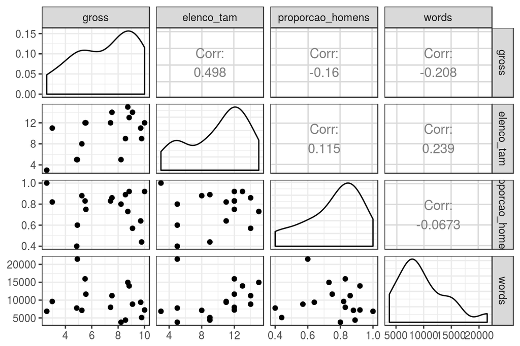

```r
d.log %>% select(-title) %>% ggpairs()
```

Organizando todas as variáveis para melho visualização:

```r
d.temp = d
d.temp$proporcao_homens = d.temp$proporcao_homens * 100
d.temp$elenco_tam = d.temp$elenco_tam * 10
d.scaled = d.temp %>%
  select(title, gross, elenco_tam, words, proporcao_homens) %>%
  mutate_each(funs(log), 2:5)
```

```r
set.seed(24)

n_clusters = 4

km = d.scaled %>%
    select(-title) %>%
    kmeans(centers = n_clusters, nstart = 20)
```

```r
d.scaled.km.long = km %>%
    augment(d.scaled) %>%
    gather(key = "variável",
           value = "valor",
           -title, -.cluster)
```

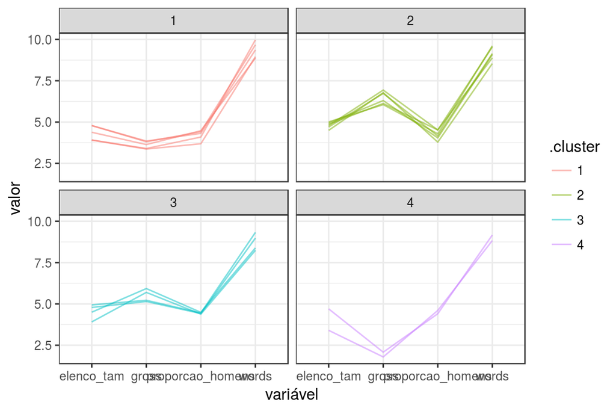

```r
d.scaled.km.long %>%
    ggplot(aes(x=`variável`, y=valor, group=title, colour=.cluster)) +
    geom_line(alpha = .5) +
    facet_wrap(~ .cluster)
```

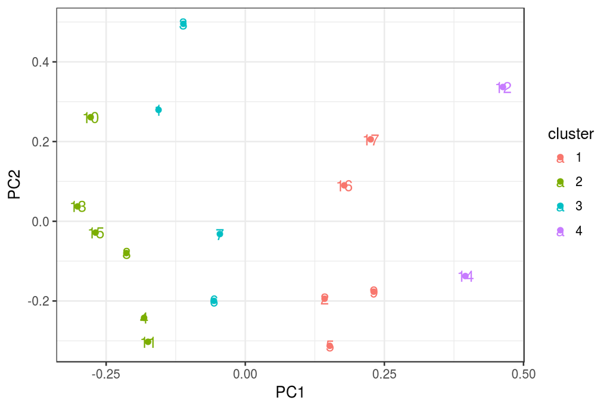

```r
autoplot(km, data=d.scaled, label = TRUE)
```

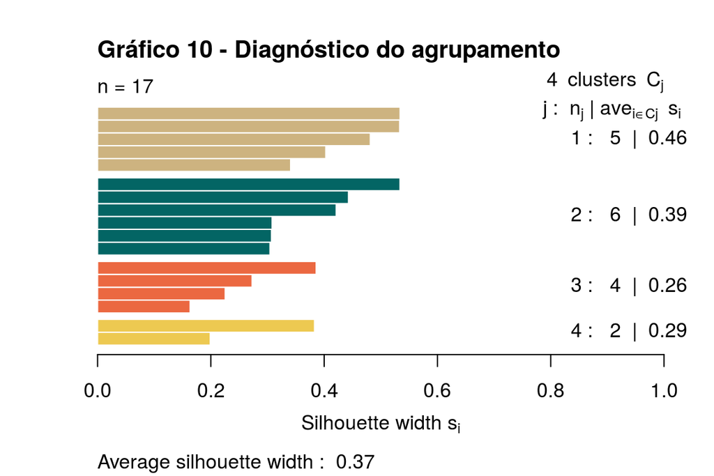

```r
dists = d.scaled %>%
    select(-title) %>%
    dist()

plot(silhouette(km$cluster, dists),
     col = c("#CDB380", "#036564", "#EB6841", "#EDC951"),
     main="Gráfico 10 - Diagnóstico do agrupamento",
     yaxt='n', ann=FALSE)
```

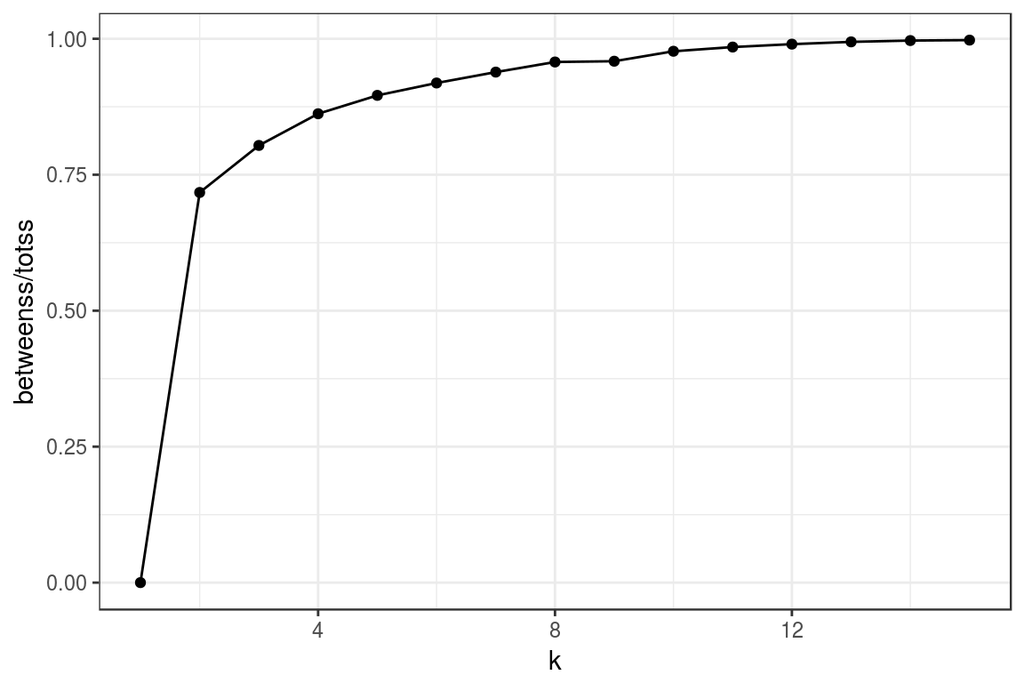

```r
explorando_k = tibble(k = 1:15) %>%
    group_by(k) %>%
    do(
        kmeans(select(d.scaled, -title),
               centers = .$k,
               nstart = 20) %>% glance()
    )
explorando_k %>%
    ggplot(aes(x = k, y = betweenss / totss)) +
    geom_line() +
    geom_point()
```